# Estimating Monotonic Effects with brms

Paul Bürkner

2025-09-09

## Introduction

This vignette is about monotonic effects, a special way of handling discrete predictors that are on an ordinal or higher scale (Bürkner & Charpentier, in review). A predictor, which we want to model as monotonic (i.e., having a monotonically increasing or decreasing relationship with the response), must either be integer valued or an ordered factor. As opposed to a continuous predictor, predictor categories (or integers) are not assumed to be equidistant with respect to their effect on the response variable. Instead, the distance between adjacent predictor categories (or integers) is estimated from the data and may vary across categories. This is realized by parameterizing as follows: One parameter, $b$, takes care of the direction and size of the effect similar to an ordinary regression parameter. If the monotonic effect is used in a linear model, $b$ can be interpreted as the expected average difference between two adjacent categories of the ordinal predictor. An additional parameter vector, $\zeta$, estimates the normalized distances between consecutive predictor categories which thus defines the shape of the monotonic effect. For a single monotonic predictor, $x$, the linear predictor term of observation $n$ looks as follows:

$$\eta_n = b D \sum_{i = 1}^{x_n}
\zeta_i$$

The parameter $b$ can take on any real value, while $\zeta$ is a simplex, which means that it satisfies $\zeta_i \in [0,1]$ and $\sum_{i = 1}^D \zeta_i = 1$ with $D$ being the number of elements of $\zeta$. Equivalently, $D$ is the number of categories (or highest integer in the data) minus 1, since we start counting categories from zero to simplify the notation.

## A Simple Monotonic Model

A main application of monotonic effects are ordinal predictors that can be modeled this way without falsely treating them either as continuous or as unordered categorical predictors. In Psychology, for instance, this kind of data is omnipresent in the form of Likert scale items, which are often treated as being continuous for convenience without ever testing this assumption. As an example, suppose we are interested in the relationship of yearly income (in $) and life satisfaction measured on an arbitrary scale from 0 to 100. Usually, people are not asked for the exact income. Instead, they are asked to rank themselves in one of certain classes, say: ‘below 20k’, ‘between 20k and 40k’, ‘between 40k and 100k’ and ‘above 100k’. We use some simulated data for illustration purposes.

```r
income_options <- c("below_20", "20_to_40", "40_to_100", "greater_100")
income <- factor(sample(income_options, 100, TRUE),
                 levels = income_options, ordered = TRUE)
mean_ls <- c(30, 60, 70, 75)
ls <- mean_ls[income] + rnorm(100, sd = 7)
dat <- data.frame(income, ls)
```

We now proceed with analyzing the data modeling `income` as a monotonic effect.

```r
fit1 <- brm(ls ~ mo(income), data = dat)
```

The summary methods yield

```r
summary(fit1)
```

```
 Family: gaussian
  Links: mu = identity
Formula: ls ~ mo(income)
   Data: dat (Number of observations: 100)
  Draws: 4 chains, each with iter = 2000; warmup = 1000; thin = 1;
         total post-warmup draws = 4000

Regression Coefficients:
          Estimate Est.Error l-95% CI u-95% CI Rhat Bulk_ESS Tail_ESS
Intercept    30.01      1.35    27.35    32.65 1.00     2541     2370
moincome     15.73      0.62    14.51    16.96 1.00     2355     2370

Monotonic Simplex Parameters:
             Estimate Est.Error l-95% CI u-95% CI Rhat Bulk_ESS Tail_ESS
moincome1[1]     0.65      0.03     0.59     0.71 1.00     2937     2336
moincome1[2]     0.26      0.04     0.19     0.33 1.00     3204     2810
moincome1[3]     0.09      0.04     0.02     0.17 1.00     2516     1670

Further Distributional Parameters:
      Estimate Est.Error l-95% CI u-95% CI Rhat Bulk_ESS Tail_ESS
sigma     6.37      0.47     5.51     7.39 1.00     2753     2597

Draws were sampled using sampling(NUTS). For each parameter, Bulk_ESS
and Tail_ESS are effective sample size measures, and Rhat is the potential
scale reduction factor on split chains (at convergence, Rhat = 1).
```

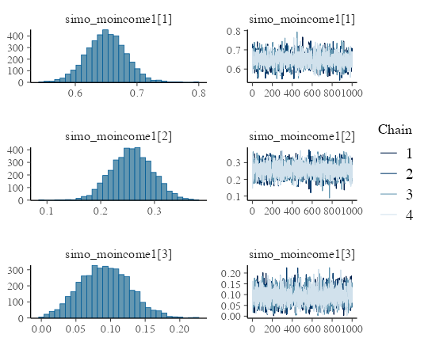

```r
plot(fit1, variable = "simo", regex = TRUE)
```

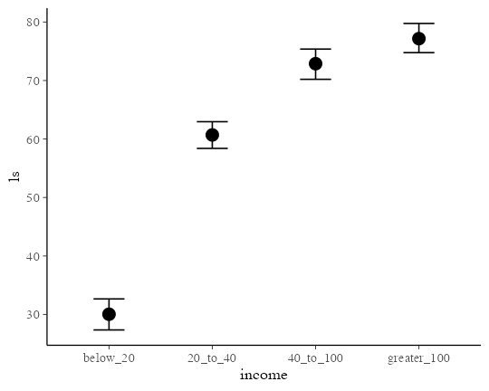

```r
plot(conditional_effects(fit1))
```

The distributions of the simplex parameter of `income`, as shown in the `plot` method, demonstrate that the largest difference (about 70% of the difference between minimum and maximum category) is between the first two categories.

Now, let’s compare of monotonic model with two common alternative models. (a) Assume `income` to be continuous:

```r
dat$income_num <- as.numeric(dat$income)
fit2 <- brm(ls ~ income_num, data = dat)
```

```r
summary(fit2)
```

```
 Family: gaussian
  Links: mu = identity
Formula: ls ~ income_num
   Data: dat (Number of observations: 100)
  Draws: 4 chains, each with iter = 2000; warmup = 1000; thin = 1;
         total post-warmup draws = 4000

Regression Coefficients:
           Estimate Est.Error l-95% CI u-95% CI Rhat Bulk_ESS Tail_ESS
Intercept     23.31      2.33    18.72    27.78 1.00     4674     3299
income_num    14.96      0.85    13.26    16.62 1.00     4684     2988

Further Distributional Parameters:
      Estimate Est.Error l-95% CI u-95% CI Rhat Bulk_ESS Tail_ESS
sigma     9.39      0.68     8.17    10.80 1.00     3867     2855

Draws were sampled using sampling(NUTS). For each parameter, Bulk_ESS
and Tail_ESS are effective sample size measures, and Rhat is the potential
scale reduction factor on split chains (at convergence, Rhat = 1).
```

or (b) Assume `income` to be an unordered factor:

```r
contrasts(dat$income) <- contr.treatment(4)
fit3 <- brm(ls ~ income, data = dat)
```

```r
summary(fit3)
```

```
 Family: gaussian
  Links: mu = identity
Formula: ls ~ income
   Data: dat (Number of observations: 100)
  Draws: 4 chains, each with iter = 2000; warmup = 1000; thin = 1;
         total post-warmup draws = 4000

Regression Coefficients:
          Estimate Est.Error l-95% CI u-95% CI Rhat Bulk_ESS Tail_ESS
Intercept    29.81      1.34    27.19    32.41 1.00     2967     2441
income2      30.93      1.75    27.52    34.42 1.00     3066     2764
income3      43.11      1.89    39.40    46.81 1.00     3368     3194
income4      47.43      1.84    43.87    51.00 1.00     3334     3081

Further Distributional Parameters:
      Estimate Est.Error l-95% CI u-95% CI Rhat Bulk_ESS Tail_ESS
sigma     6.36      0.46     5.54     7.33 1.00     3929     3018

Draws were sampled using sampling(NUTS). For each parameter, Bulk_ESS
and Tail_ESS are effective sample size measures, and Rhat is the potential
scale reduction factor on split chains (at convergence, Rhat = 1).
```

We can easily compare the fit of the three models using leave-one-out cross-validation.

```r
loo(fit1, fit2, fit3)
```

```
Output of model 'fit1':

Computed from 4000 by 100 log-likelihood matrix.

         Estimate   SE
elpd_loo   -328.9  6.5
p_loo         4.7  0.6
looic       657.7 13.1
------
MCSE of elpd_loo is 0.0.
MCSE and ESS estimates assume MCMC draws (r_eff in [0.6, 1.0]).

All Pareto k estimates are good (k < 0.7).
See help('pareto-k-diagnostic') for details.

Output of model 'fit2':

Computed from 4000 by 100 log-likelihood matrix.

         Estimate   SE
elpd_loo   -366.6  5.5
p_loo         2.5  0.3
looic       733.1 11.1
------
MCSE of elpd_loo is 0.0.
MCSE and ESS estimates assume MCMC draws (r_eff in [0.8, 1.2]).

All Pareto k estimates are good (k < 0.7).
See help('pareto-k-diagnostic') for details.

Output of model 'fit3':

Computed from 4000 by 100 log-likelihood matrix.

         Estimate   SE
elpd_loo   -328.8  6.6
p_loo         4.7  0.6
looic       657.7 13.2
------
MCSE of elpd_loo is 0.0.
MCSE and ESS estimates assume MCMC draws (r_eff in [0.7, 1.3]).

All Pareto k estimates are good (k < 0.7).
See help('pareto-k-diagnostic') for details.

Model comparisons:
     elpd_diff se_diff
fit3   0.0       0.0
fit1   0.0       0.1
fit2 -37.7       6.2
```

The monotonic model fits better than the continuous model, which is not surprising given that the relationship between `income` and `ls` is non-linear. The monotonic and the unordered factor model have almost identical fit in this example, but this may not be the case for other data sets.

## Setting Prior Distributions

In the previous monotonic model, we have implicitly assumed that all differences between adjacent categories were a-priori the same, or formulated correctly, had the same prior distribution. In the following, we want to show how to change this assumption. The canonical prior distribution of a simplex parameter is the Dirichlet distribution, a multivariate generalization of the beta distribution. It is non-zero for all valid simplexes (i.e., $\zeta_i \in [0,1]$ and $\sum_{i = 1}^D \zeta_i = 1$) and zero otherwise. The Dirichlet prior has a single parameter $\alpha$ of the same length as $\zeta$. The higher $\alpha_i$ the higher the a-priori probability of higher values of $\zeta_i$. Suppose that, before looking at the data, we expected that the same amount of additional money matters more for people who generally have less money. This translates into a higher a-priori values of $\zeta_1$ (difference between ‘below_20’ and ‘20_to_40’) and hence into higher values of $\alpha_1$. We choose $\alpha_1 = 2$ and $\alpha_2 = \alpha_3 = 1$, the latter being the default value of $\alpha$. To fit the model we write:

```r
prior4 <- prior(dirichlet(c(2, 1, 1)), class = "simo", coef = "moincome1")
fit4 <- brm(ls ~ mo(income), data = dat,
            prior = prior4, sample_prior = TRUE)
```

The `1` at the end of `"moincome1"` may appear strange when first working with monotonic effects. However, it is necessary as one monotonic term may be associated with multiple simplex parameters, if interactions of multiple monotonic variables are included in the model.

```r
summary(fit4)
```

```
 Family: gaussian
  Links: mu = identity
Formula: ls ~ mo(income)
   Data: dat (Number of observations: 100)
  Draws: 4 chains, each with iter = 2000; warmup = 1000; thin = 1;
         total post-warmup draws = 4000

Regression Coefficients:
          Estimate Est.Error l-95% CI u-95% CI Rhat Bulk_ESS Tail_ESS
Intercept    30.01      1.40    27.25    32.74 1.00     2385     2054
moincome     15.72      0.63    14.47    16.94 1.00     2073     1925

Monotonic Simplex Parameters:
             Estimate Est.Error l-95% CI u-95% CI Rhat Bulk_ESS Tail_ESS
moincome1[1]     0.65      0.03     0.59     0.71 1.00     2573     2446
moincome1[2]     0.26      0.04     0.18     0.33 1.00     3616     2583
moincome1[3]     0.09      0.04     0.02     0.16 1.00     2620     1386

Further Distributional Parameters:
      Estimate Est.Error l-95% CI u-95% CI Rhat Bulk_ESS Tail_ESS
sigma     6.38      0.48     5.56     7.40 1.00     2731     2276

Draws were sampled using sampling(NUTS). For each parameter, Bulk_ESS
and Tail_ESS are effective sample size measures, and Rhat is the potential
scale reduction factor on split chains (at convergence, Rhat = 1).
```

We have used `sample_prior = TRUE` to also obtain draws from the prior distribution of `simo_moincome1` so that we can visualized it.

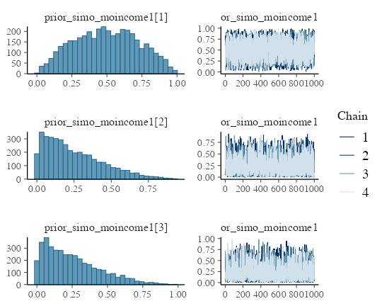

```r
plot(fit4, variable = "prior_simo", regex = TRUE, N = 3)
```

As is visible in the plots, `simo_moincome1[1]` was a-priori on average twice as high as `simo_moincome1[2]` and `simo_moincome1[3]` as a result of setting $\alpha_1$ to 2.

## Modeling interactions of monotonic variables

Suppose, we have additionally asked participants for their age.

```r
dat$age <- rnorm(100, mean = 40, sd = 10)
```

We are not only interested in the main effect of age but also in the interaction of income and age. Interactions with monotonic variables can be specified in the usual way using the `*` operator:

```r
fit5 <- brm(ls ~ mo(income)*age, data = dat)
```

```r
summary(fit5)
```

```
 Family: gaussian
  Links: mu = identity
Formula: ls ~ mo(income) * age
   Data: dat (Number of observations: 100)
  Draws: 4 chains, each with iter = 2000; warmup = 1000; thin = 1;
         total post-warmup draws = 4000

Regression Coefficients:
             Estimate Est.Error l-95% CI u-95% CI Rhat Bulk_ESS Tail_ESS
Intercept       26.27      5.71    16.06    38.52 1.01      849     1233
age              0.10      0.15    -0.23     0.35 1.01      808     1017
moincome        16.98      2.66    11.42    22.00 1.01      704     1087
moincome:age    -0.03      0.07    -0.16     0.11 1.01      683     1067

Monotonic Simplex Parameters:
                 Estimate Est.Error l-95% CI u-95% CI Rhat Bulk_ESS Tail_ESS
moincome1[1]         0.62      0.06     0.49     0.74 1.00     1169     1471
moincome1[2]         0.26      0.05     0.17     0.37 1.00     2478     2075
moincome1[3]         0.12      0.06     0.02     0.25 1.00     1284     1427
moincome:age1[1]     0.32      0.24     0.01     0.86 1.00     1457     1820
moincome:age1[2]     0.32      0.23     0.01     0.82 1.00     2537     2500
moincome:age1[3]     0.36      0.25     0.01     0.87 1.00     1817     2428

Further Distributional Parameters:
      Estimate Est.Error l-95% CI u-95% CI Rhat Bulk_ESS Tail_ESS
sigma     6.40      0.47     5.55     7.39 1.00     2828     2151

Draws were sampled using sampling(NUTS). For each parameter, Bulk_ESS
and Tail_ESS are effective sample size measures, and Rhat is the potential
scale reduction factor on split chains (at convergence, Rhat = 1).
```

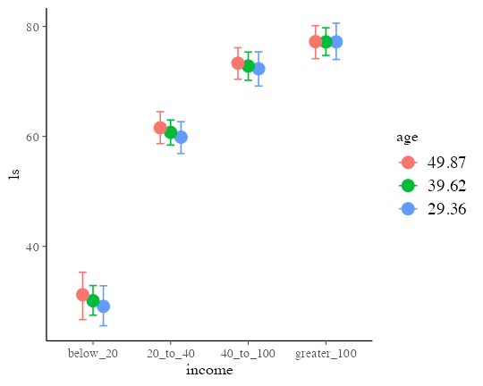

```r
conditional_effects(fit5, "income:age")
```

## Modelling Monotonic Group-Level Effects

Suppose that the 100 people in our sample data were drawn from 10 different cities; 10 people per city. Thus, we add an identifier for `city` to the data and add some city-related variation to `ls`.

```r
dat$city <- rep(1:10, each = 10)
var_city <- rnorm(10, sd = 10)
dat$ls <- dat$ls + var_city[dat$city]
```

With the following code, we fit a multilevel model assuming the intercept and the effect of `income` to vary by city:

```r
fit6 <- brm(ls ~ mo(income)*age + (mo(income) | city), data = dat)
```

```r
summary(fit6)
```

```
 Family: gaussian
  Links: mu = identity
Formula: ls ~ mo(income) * age + (mo(income) | city)
   Data: dat (Number of observations: 100)
  Draws: 4 chains, each with iter = 2000; warmup = 1000; thin = 1;
         total post-warmup draws = 4000

Multilevel Hyperparameters:
~city (Number of levels: 10)
                        Estimate Est.Error l-95% CI u-95% CI Rhat Bulk_ESS Tail_ESS
sd(Intercept)               8.19      2.66     4.16    14.46 1.00     1505     2276
sd(moincome)                0.91      0.75     0.04     2.83 1.00     1400     1695
cor(Intercept,moincome)    -0.03      0.54    -0.92     0.93 1.00     3727     2121

Regression Coefficients:
             Estimate Est.Error l-95% CI u-95% CI Rhat Bulk_ESS Tail_ESS
Intercept       19.84      6.58     7.82    33.92 1.00      982      963
age              0.08      0.15    -0.28     0.36 1.00      960      902
moincome        17.24      2.94    11.07    22.65 1.00      880     1014
moincome:age    -0.04      0.07    -0.17     0.12 1.00      853      864

Monotonic Simplex Parameters:
                 Estimate Est.Error l-95% CI u-95% CI Rhat Bulk_ESS Tail_ESS
moincome1[1]         0.61      0.06     0.48     0.74 1.00     1485     1678
moincome1[2]         0.25      0.05     0.15     0.36 1.00     3505     2694
moincome1[3]         0.14      0.06     0.03     0.27 1.00     1640     1381
moincome:age1[1]     0.32      0.24     0.01     0.86 1.00     1733     1390
moincome:age1[2]     0.33      0.23     0.01     0.82 1.00     3460     2759
moincome:age1[3]     0.35      0.23     0.01     0.84 1.00     2391     2829

Further Distributional Parameters:
      Estimate Est.Error l-95% CI u-95% CI Rhat Bulk_ESS Tail_ESS
sigma     6.49      0.52     5.56     7.57 1.00     3861     2787

Draws were sampled using sampling(NUTS). For each parameter, Bulk_ESS
and Tail_ESS are effective sample size measures, and Rhat is the potential
scale reduction factor on split chains (at convergence, Rhat = 1).
```

reveals that the effect of `income` varies only little across cities. For the present data, this is not overly surprising given that, in the data simulations, we assumed `income` to have the same effect across cities.

## References

Bürkner P. C. & Charpentier, E. (in review). [Monotonic Effects: A Principled Approach for Including Ordinal Predictors in Regression Models](https://osf.io/preprints/psyarxiv/9qkhj/). *PsyArXiv preprint*.